# hw1 Ryan Wang

2025-02-02

# I

### 1.

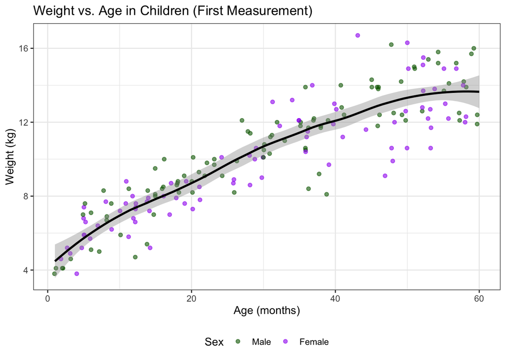

```r
# Extract first measurement per child
first_measurements <- data %>%
  group_by(id) %>%
  arrange(num) %>%  # measurement time
  slice(1) %>%
  ungroup() %>%
  mutate(
    wt = as.numeric(wt),
    ht = as.numeric(ht),
    arm = as.numeric(arm)
  ) %>%
  mutate(
    sex = factor(sex,
                 levels = c(1, 2),
                 labels = c("Male", "Female"))
  ) %>%
  filter(!is.na(wt))


ggplot(first_measurements, aes(x = age, y = wt)) +
  geom_point(
    aes(color = factor(sex)),
    position = position_jitter(width = 0.3, height = 0),
    alpha = 0.6
  ) +
  geom_smooth(
    method = "loess",
    formula = y ~ x,
    span = 0.5,
    se = T,
    color = "black"
  ) +
  # Customize colors and labels
  scale_color_manual(
    values = c("Female" = "purple", "Male" = "darkgreen"),
    name = "Sex"
  ) +
  labs(
    x = "Age (months)",
    y = "Weight (kg)",
    color = "Sex",
    title = "Weight vs. Age in Children (First Measurement)"
  ) +
  theme_bw() +
  theme(legend.position = "bottom")
```

The weights of 185 children ranging from 1 to 60 months of age were plotted as a function of age. The average (SD) weight of 12 month olds is approximately 7 (0.5) kg, respectively. Average and SD of weight increases with age such that the average (SD) weight is approximately 12 (1) and 14 (1.5) for children aged 40 and 60 months, respectively.  
### 2.

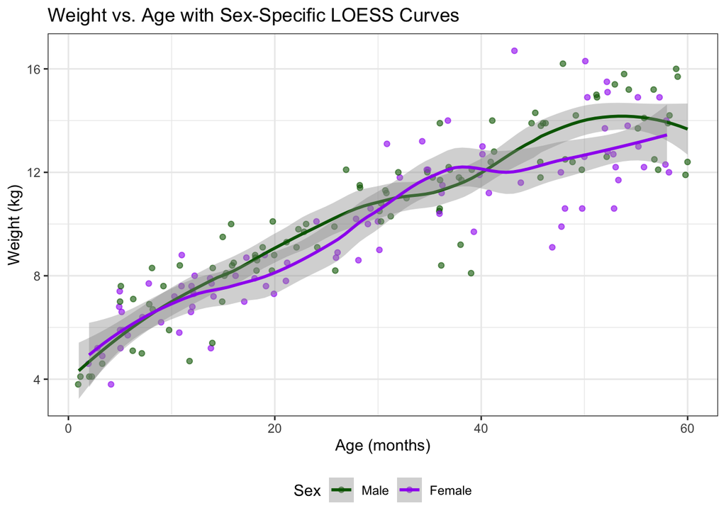

```r
ggplot(first_measurements, aes(x = age, y = wt, color = sex)) +
  geom_point(
    position = position_jitter(width = 0.3, height = 0),
    alpha = 0.6
  ) +
  # Separate LOESS curves for each sex
  geom_smooth(
    method = "loess",
    formula = y ~ x,
    span = 0.5,
    se = T,
    linewidth = 1
  ) +
  scale_color_manual(
    values = c("Male" = "darkgreen", "Female" = "purple"),
    name = "Sex"
  ) +
  labs(
    x = "Age (months)",
    y = "Weight (kg)",
    title = "Weight vs. Age with Sex-Specific LOESS Curves"
  ) +
  theme_bw() +
  theme(legend.position = "bottom")
```

Male weight increases steadily and linearly from 0 to 30 months, slows down from 30 to 40 months, accelerates from 40 to 50 months, and then shows no significant change from 50 to 60 months. Female weight also increases linearly but slows slightly from 10 to 30 months and accelerates from 30 to 40 months. Overall, there is no significant difference in the average weight between males and females over the 60-month period.

### 3.

```r
model_slr <- lm(wt ~ age, data = first_measurements)
summary(model_slr)
```

```
##
## Call:
## lm(formula = wt ~ age, data = first_measurements)
##
## Residuals:
##     Min      1Q  Median      3Q     Max
## -3.7237 -0.8276  0.1854  0.9183  4.5043
##
## Coefficients:
##             Estimate Std. Error t value Pr(>|t|)
## (Intercept) 5.444528   0.204316   26.65   <2e-16 ***
## age         0.157003   0.005845   26.86   <2e-16 ***
## ---
## Signif. codes:  0 '***' 0.001 '**' 0.01 '*' 0.05 '.' 0.1 ' ' 1
##
## Residual standard error: 1.401 on 183 degrees of freedom
## Multiple R-squared:  0.7977, Adjusted R-squared:  0.7966
## F-statistic: 721.4 on 1 and 183 DF,  p-value: < 2.2e-16
```

### 4.

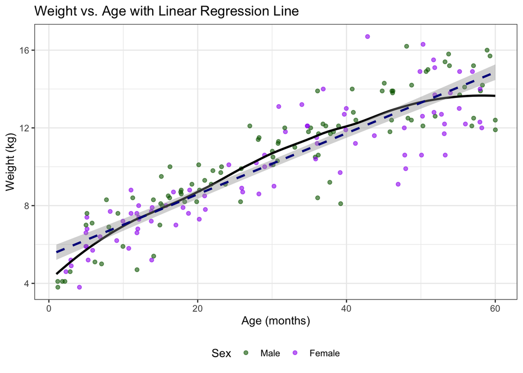

```r
ggplot(first_measurements, aes(x = age, y = wt)) +
  geom_point(
    aes(color = factor(sex)),
    position = position_jitter(width = 0.3, height = 0),
    alpha = 0.6
  ) +
  geom_smooth(
    method = "loess",
    formula = y ~ x,
    span = 0.5,
    color = "black",
    se = FALSE,
    linewidth = 1
  ) +
  geom_smooth(
    method = "lm",
    formula = y ~ x,
    color = "darkblue",
    linetype = "dashed",
    se = T,
    aes(group = 1)
  ) +
  scale_color_manual(
    values = c("Male" = "darkgreen", "Female" = "purple"),
    name = "Sex"
  ) +
  labs(
    x = "Age (months)",
    y = "Weight (kg)",
    title = "Weight vs. Age with Linear Regression Line"
  ) +
  theme_bw() +
  theme(legend.position = "bottom")
```

1. The linearity assumption seems valid as we see that the regression line is close to the loess curve for the 0-60 months range.
2. The homoscedasticity does not hold as we see that the variance is smaller for the children under 30 months, but greater for children over 30 months.

# II

### 1.

```r
# a
first_measurements <- first_measurements %>%
  mutate(
    age_c = age - 6,
    age_sp6 = ifelse(age - 6 > 0, age - 6, 0),
    age_sp12 = ifelse(age - 12 > 0, age - 12, 0)
  )

# b
model_spline <- lm(wt ~ age_c + age_sp6 + age_sp12, data = first_measurements)
summary(model_spline)
```

```
##
## Call:
## lm(formula = wt ~ age_c + age_sp6 + age_sp12, data = first_measurements)
##
## Residuals:
##     Min      1Q  Median      3Q     Max
## -3.6698 -0.7883  0.0106  0.8976  4.5171
##
## Coefficients:
##             Estimate Std. Error t value Pr(>|t|)
## (Intercept)   6.5171     0.4022  16.205  < 2e-16 ***
## age_c         0.5285     0.1678   3.150  0.00191 **
## age_sp6      -0.3423     0.2265  -1.511  0.13250
## age_sp12     -0.0394     0.0817  -0.482  0.63025
## ---
## Signif. codes:  0 '***' 0.001 '**' 0.01 '*' 0.05 '.' 0.1 ' ' 1
##
## Residual standard error: 1.368 on 181 degrees of freedom
## Multiple R-squared:  0.809,  Adjusted R-squared:  0.8058
## F-statistic: 255.5 on 3 and 181 DF,  p-value: < 2.2e-16
```

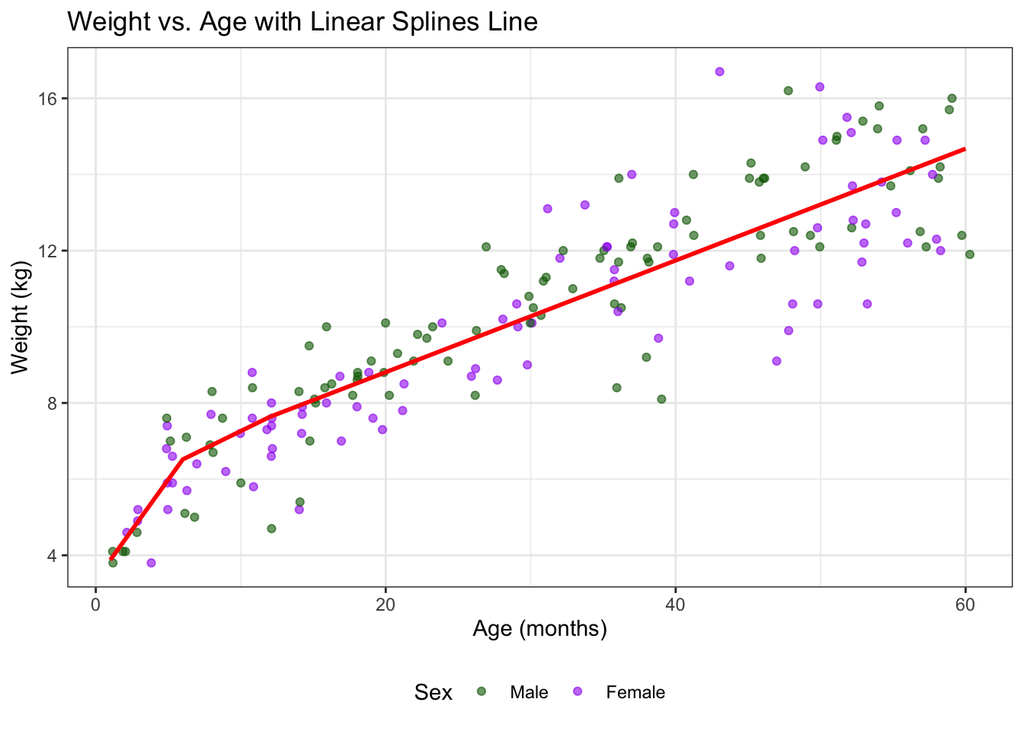

```r
# c
ggplot(first_measurements, aes(x = age, y = wt)) +
  geom_point(
    aes(color = factor(sex)),
    position = position_jitter(width = 0.3, height = 0),
    alpha = 0.6
  ) +
  geom_line(aes(y = fitted(model_spline)), color = "red", linewidth = 1) +
  scale_color_manual(
    values = c("Male" = "darkgreen", "Female" = "purple"),
    name = "Sex"
  ) +
  labs(
    x = "Age (months)",
    y = "Weight (kg)",
    title = "Weight vs. Age with Linear Splines Line"
  ) +
  theme_bw() +
  theme(legend.position = "bottom")
```

age_c (0.5285): For every additional month of age, the average weight increases by about 0.53 kilograms with a standard deviation of 0.167, assuming no additional effects at 6 or 12 months (95% confidence interval: 0.20 to 0.86 kilograms per month).

age_sp6 (-0.3423): Among children 6 to 12 months of age, the difference in average weight comparing children whose age differ by one month is 0.5285-0.3423 = 0.1862  
age_sp6 is the difference between the average monthly change in weight comparing children 6 to 12 vs. under 6 months of age. (95% confidence interval: -0.79 to 0.11 kilograms).

So, the overall growth pattern is linear, with non-significant variations at these specific age points.

### 2.

```r
# a
first_measurements <- first_measurements %>%
  mutate(
    age_c = age - 6,
    age2 = (age - 6)^2,
    age3 = (age - 6)^3,
    age_csp1 = pmax(age - 6, 0)^3)

# b
model_cubic <- lm(wt ~ age_c + age2 + age3 + age_csp1, data = first_measurements)
summary(model_cubic)
```

```
##
## Call:
## lm(formula = wt ~ age_c + age2 + age3 + age_csp1, data = first_measurements)
##
## Residuals:
##     Min      1Q  Median      3Q     Max
## -3.9372 -0.8113  0.0994  0.7262  4.1256
##
## Coefficients:
##              Estimate Std. Error t value Pr(>|t|)
## (Intercept)  6.233515   0.258945  24.073  < 2e-16 ***
## age_c        0.165051   0.047202   3.497 0.000593 ***
## age2         0.001623   0.002234   0.726 0.468502
## age3         0.015562   0.008252   1.886 0.060912 .
## age_csp1    -0.015601   0.008265  -1.888 0.060695 .
## ---
## Signif. codes:  0 '***' 0.001 '**' 0.01 '*' 0.05 '.' 0.1 ' ' 1
##
## Residual standard error: 1.332 on 180 degrees of freedom
## Multiple R-squared:   0.82,  Adjusted R-squared:  0.8159
## F-statistic: 204.9 on 4 and 180 DF,  p-value: < 2.2e-16
```

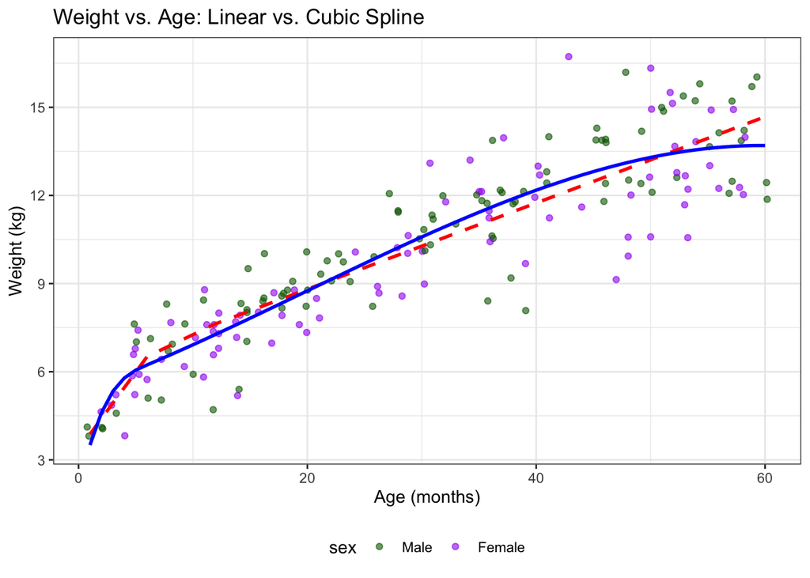

```r
# c
ggplot(first_measurements, aes(x = age, y = wt)) +
  geom_point(
    aes(color = sex),
    position = position_jitter(width = 0.3),
    alpha = 0.6
  ) +
  # Linear spline
  geom_line(aes(y = fitted(model_spline)), color = "red", linetype = "dashed", linewidth = 1) +
  # Cubic spline
  geom_line(aes(y = fitted(model_cubic)), color = "blue", linewidth = 1) +
  labs(
    x = "Age (months)",
    y = "Weight (kg)",
    title = "Weight vs. Age: Linear vs. Cubic Spline"
  ) +
  scale_color_manual(values = c("Male" = "darkgreen", "Female" = "purple")) +
  theme_bw() +
  theme(legend.position = "bottom")
```

4. Linear Spline shows piece-wise linear relation between weight and age with more abrupt slope changes at knots (age = 6, 12). Cubic Spline is a more smooth curve through the data, allowing gradual changes in slope at knots. The slope of the cubic spline gradually decreases to 0 at age approaches 60.

### 3.

```r
# b
model_ns <- lm(wt ~ ns(age, df = 3), data = first_measurements)
summary(model_ns)
```

```
##
## Call:
## lm(formula = wt ~ ns(age, df = 3), data = first_measurements)
##
## Residuals:
##     Min      1Q  Median      3Q     Max
## -3.9308 -0.8202  0.1021  0.7982  4.1894
##
## Coefficients:
##                  Estimate Std. Error t value Pr(>|t|)
## (Intercept)        4.8919     0.3471   14.09   <2e-16 ***
## ns(age, df = 3)1   6.4816     0.4253   15.24   <2e-16 ***
## ns(age, df = 3)2  11.8892     0.8737   13.61   <2e-16 ***
## ns(age, df = 3)3   6.8342     0.3321   20.58   <2e-16 ***
## ---
## Signif. codes:  0 '***' 0.001 '**' 0.01 '*' 0.05 '.' 0.1 ' ' 1
##
## Residual standard error: 1.344 on 181 degrees of freedom
## Multiple R-squared:  0.8158, Adjusted R-squared:  0.8128
## F-statistic: 267.3 on 3 and 181 DF,  p-value: < 2.2e-16
```

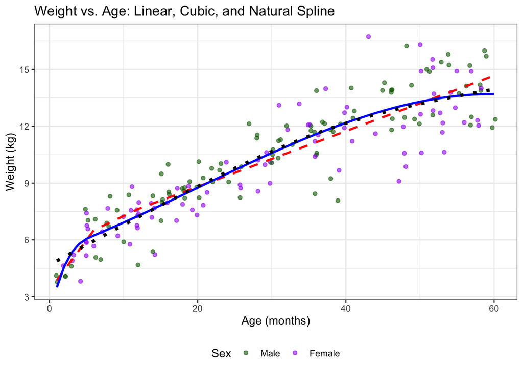

```r
# c
ggplot(first_measurements, aes(x = age, y = wt)) +
  geom_point(
    aes(color = sex),
    position = position_jitter(width = 0.3),
    alpha = 0.6
  ) +
  # Linear spline
  geom_line(aes(y = fitted(model_spline)), color = "red", linetype = "dashed", linewidth = 1) +
  # Cubic regression spline
  geom_line(aes(y = fitted(model_cubic)), color = "blue", linewidth = 1) +
  # Natural cubic spline
  geom_line(aes(y = fitted(model_ns)), color = "black", linetype = "dotted", linewidth = 1.5) +
  labs(
    x = "Age (months)",
    y = "Weight (kg)",
    title = "Weight vs. Age: Linear, Cubic, and Natural Spline"
  ) +
  scale_color_manual(values = c("Male" = "darkgreen", "Female" = "purple")) +
  theme_bw() +
  theme(legend.position = "bottom") +
  guides(color = guide_legend(title = "Sex"))
```

4. The natural spline is the most smooth curve among the three and shows no abrupt slope changes at knots. In fact, the three curve do not differ by a lot except around the knot where age = 6. The cubic regression spline seems to be the most consistent with the observed data as it has the highest $R^2$ value among the three (Multiple R-squared: 0.82).

```r
X <- model.matrix(model_ns)

XtX_inv <- solve(t(X) %*% X)
H <- X %*% XtX_inv %*% t(X)
dim(H)
```

```
## [1] 185 185
```

```r
# Find the indices of the children with ages 12, 24, and 48
selected_indices <- sapply(c(12, 24, 48), function(a) which(first_measurements$age == a)[1])
H_selected <- H[selected_indices, ]
dim(H_selected)
```

```
## [1]   3 185
```

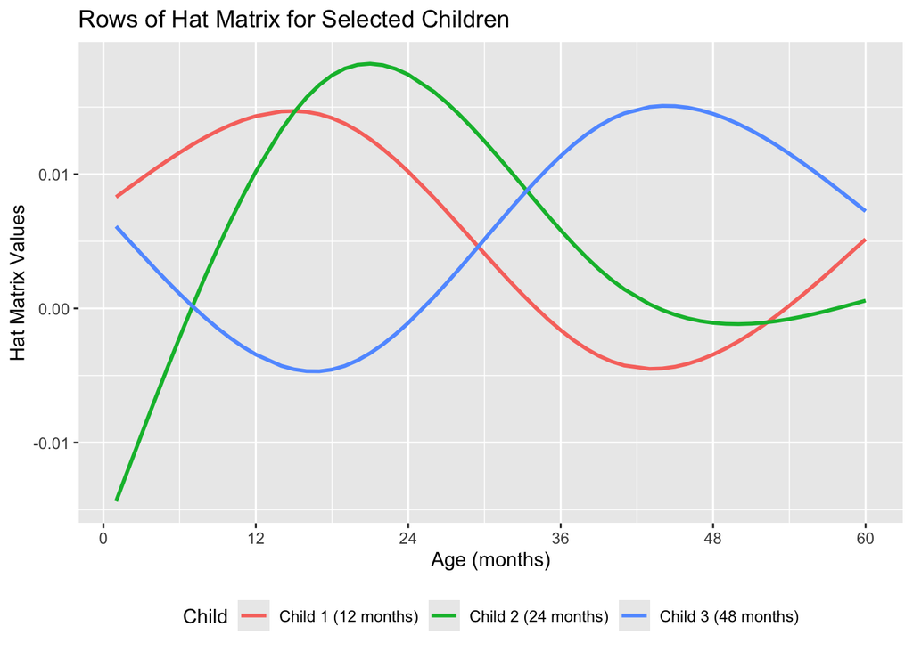

```r
H_plot_data <- data.frame(
age = rep(first_measurements$age, times = 3),
child = rep(c("Child 1 (12 months)", "Child 2 (24 months)", "Child 3 (48 months)"), each = ncol(H_selected)),
h_value = as.vector(t(H_selected))
) %>% arrange(child, h_value)

ggplot(H_plot_data, aes(x = age, y = h_value, color = child)) + geom_line(size = 1) +
scale_x_continuous(
breaks = seq(0, 60, by = 12))+
labs(
title = "Rows of Hat Matrix for Selected Children", x = "Age (months)",
y = "Hat Matrix Values",
color = "Child"
) +
theme(legend.position = "bottom")
```

# III

### 1.

```r
set.seed(23)

# Create 10-fold CV splits
rows <- 1:nrow(first_measurements)
shuffled_rows <- sample(rows, replace = F)
#head(shuffled_rows)

B <- 10
folds <- cut(rows, breaks = B, labels = F)
```

### 2.

```r
# Initialize error storage
cv_errors <- matrix(NA, nrow = 10, ncol = 8)  # 10 folds × 8 df values
noncv_errors <- numeric(8)

for (df in 1:8) {
  # Non-CV
  model_full <- lm(wt ~ ns(age, df = df), data = first_measurements)
  noncv_errors[df] <- sum(resid(model_full)^2)  # Sum of squared residuals

  # 10-fold CV
  for (fold in 1:10) {
    # Split data
    test_rows <- shuffled_rows[which(folds==fold)]
    train_rows <- shuffled_rows[which(folds!=fold)]

    test_data <- first_measurements[test_rows, ]
    train_data <- first_measurements[train_rows, ]

    # Fit model on training data
    model_cv <- lm(wt ~ ns(age, df = df), data = train_data)

    # Predict on test data and compute error
    predictions <- predict(model_cv, newdata = test_data)
    cv_errors[fold, df] <- sum((test_data$wt - predictions)^2, na.rm = TRUE)
  }
  total_cv_error <- colSums(cv_errors)  # SSR for each df
}

# final error data
error_df <- data.frame(
  df = rep(1:8, 2),
  type = rep(c("CV Error", "Training Error"), each = 8),
  error = c(total_cv_error, noncv_errors)
)
```

### 3.

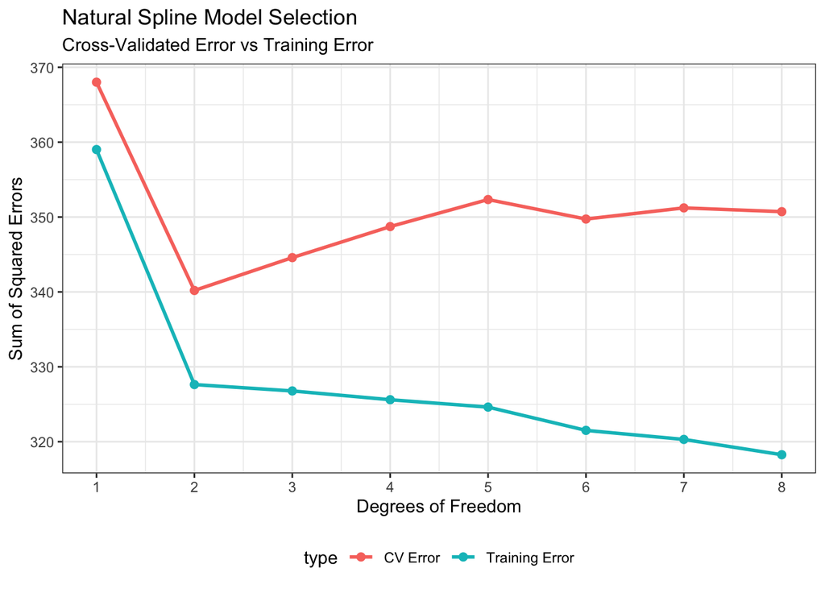

```r
ggplot(error_df, aes(x = df, y = error, color = type)) +
  geom_line(linewidth = 1) +
  geom_point(size = 2) +
  labs(
    x = "Degrees of Freedom",
    y = "Sum of Squared Errors",
    title = "Natural Spline Model Selection",
    subtitle = "Cross-Validated Error vs Training Error"
  ) +
  scale_x_continuous(breaks = 1:8) +
  theme_bw() +
  theme(legend.position = "bottom")
```

### 4.

The non-CV prediction error decreases as the degrees of freedom increases from 1 to 8 and more parameters are included.

### 5.

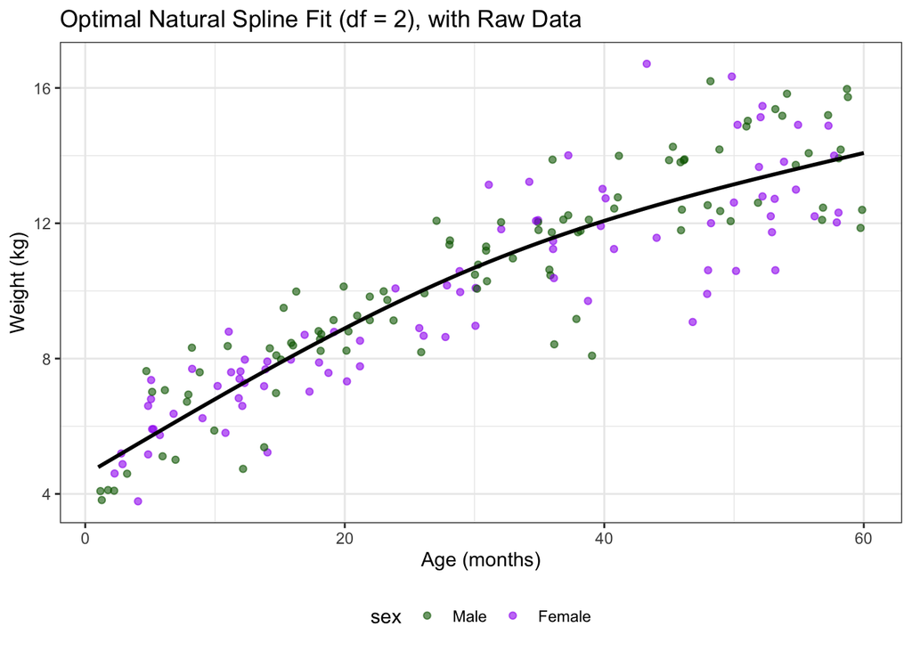

```r
optimal_df <- which.min(total_cv_error) # 2
model_optimal <- lm(wt ~ ns(age, df = optimal_df), data = first_measurements)

# Add fitted values to data
first_measurements$fitted_optimal <- fitted(model_optimal)

ggplot(first_measurements, aes(x = age, y = wt)) +
  geom_point(
    aes(color = sex),
    position = position_jitter(width = 0.3),
    alpha = 0.6
  ) +
  geom_line(
    aes(y = fitted_optimal),
    linewidth = 1
  ) +
  labs(
    x = "Age (months)",
    y = "Weight (kg)",
    title = "Optimal Natural Spline Fit (df = 2), with Raw Data"
  ) +
  scale_color_manual(values = c("Male" = "darkgreen", "Female" = "purple")) +
  theme_bw() +
  theme(legend.position = "bottom")
```

### 6.

Methods To find the optimal model for predicting child weight based on age, we conducted a cross-validation analysis using natural cubic splines. We evaluated models with df values from 1 to 8 using 10-fold cross-validation. The data was randomly partitioned into 10 subsets; for each df, models were trained iteratively on 9 subsets and tested on the remaining subset. Prediction accuracy was evaluated by summing the squared differences between observed and predicted weights across all validation folds. For comparison, training errors (non-cross-validated) were computed using the full dataset. The cross-validation balances model flexibility and generalizability to avoid overfitting.

# IV

### 1.

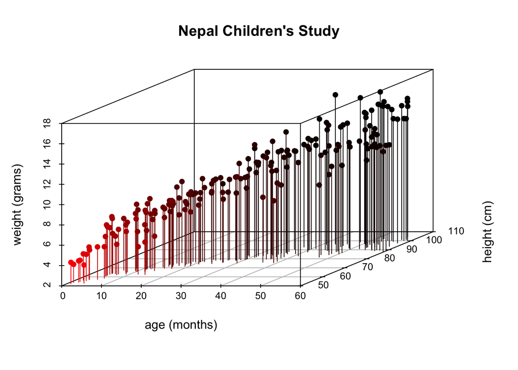

```r
plot3d(first_measurements$age,first_measurements$ht,first_measurements$wt)
scatterplot3d(first_measurements$age,first_measurements$ht,first_measurements$wt,pch=16,type="h",highlight.3d=TRUE,xlab="age (months)",ylab="height (cm)",zlab="weight (grams)",main="Nepal Children's Study")
```

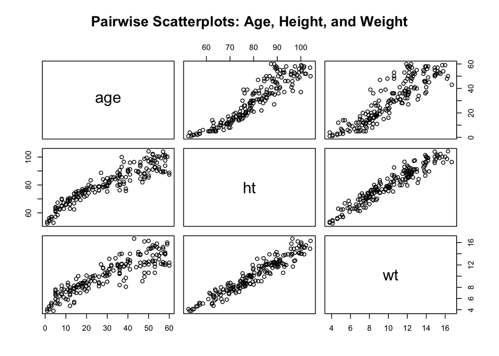

```r
pairs(first_measurements[, c("age", "ht", "wt")],
main = "Pairwise Scatterplots: Age, Height, and Weight")
```

### 2.

```r
model_mlr <- lm(wt ~ age + ht, data = first_measurements)
summary(model_mlr)
```

```
##
## Call:
## lm(formula = wt ~ age + ht, data = first_measurements)
##
## Residuals:
##      Min       1Q   Median       3Q      Max
## -2.48498 -0.53548  0.01508  0.51986  2.77917
##
## Coefficients:
##              Estimate Std. Error t value Pr(>|t|)
## (Intercept) -8.297442   0.865929  -9.582   <2e-16 ***
## age          0.005368   0.010169   0.528    0.598
## ht           0.228086   0.014205  16.057   <2e-16 ***
## ---
## Signif. codes:  0 '***' 0.001 '**' 0.01 '*' 0.05 '.' 0.1 ' ' 1
##
## Residual standard error: 0.9035 on 182 degrees of freedom
## Multiple R-squared:  0.9163, Adjusted R-squared:  0.9154
## F-statistic: 995.8 on 2 and 182 DF,  p-value: < 2.2e-16
```

The model suggests that a person with an age of 0 years and a height of 0 cm would weigh about -8.297 kg, which is not practical in reality.

For every additional centimeter in height, the average weight of a child would increase by about 0.2281 kg. It is statistically significant, and the 95% confidence interval for this increase is from 0.200 kg to 0.256 kg. The residual standard error of 0.9035 mean that the average difference between the actual weights and the predicted weights is about 0.9035 kg.

### 3.

```r
# Obtain residuals R(Y=wt|Z=ht) and R(X=age|Z=ht)
first_measurements <- first_measurements %>%
  mutate(resid.wt1 = lm(wt ~ ht, data = first_measurements)$residuals,
         resid.age1 = lm(age ~ ht, data = first_measurements)$residuals)

# Run the model of R(Y|Z) on R(X|Z)
resid.model1 <- lm(resid.wt1 ~ resid.age1, data = first_measurements)
summary(resid.model1)
```

```
##
## Call:
## lm(formula = resid.wt1 ~ resid.age1, data = first_measurements)
##
## Residuals:
##      Min       1Q   Median       3Q      Max
## -2.48498 -0.53548  0.01508  0.51986  2.77917
##
## Coefficients:
##               Estimate Std. Error t value Pr(>|t|)
## (Intercept) -2.778e-17  6.624e-02   0.000    1.000
## resid.age1   5.368e-03  1.014e-02   0.529    0.597
##
## Residual standard error: 0.901 on 183 degrees of freedom
## Multiple R-squared:  0.001529,   Adjusted R-squared:  -0.003927
## F-statistic: 0.2802 on 1 and 183 DF,  p-value: 0.5972
```

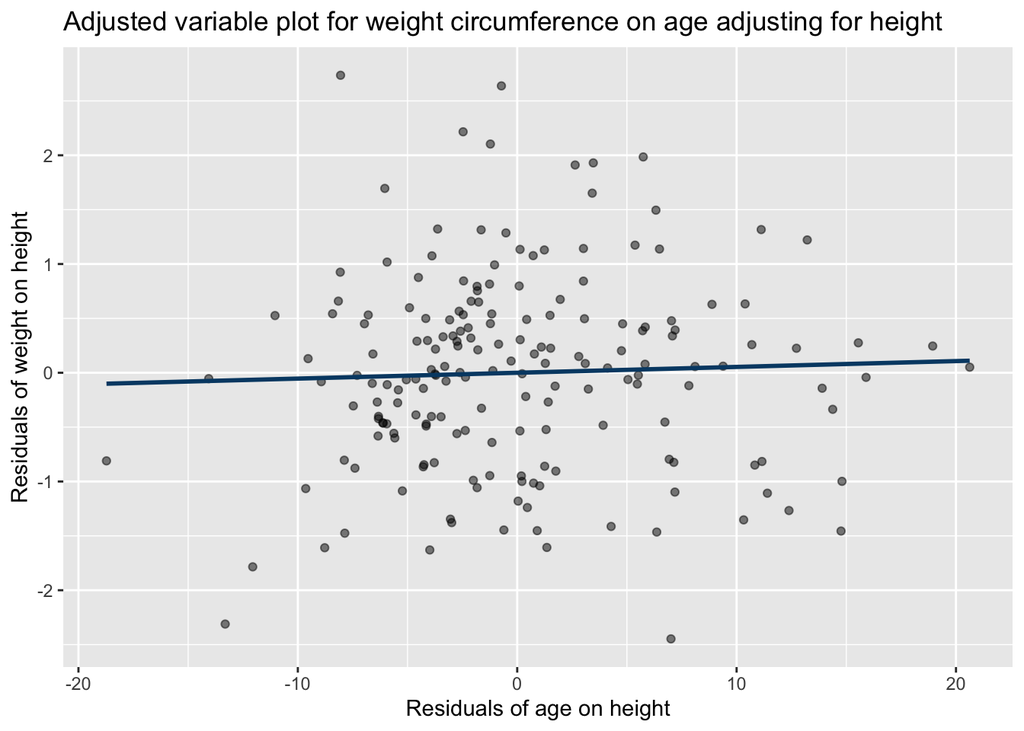

```r
# Plot the estimates and we add a fitted line
ggplot(data = first_measurements,
                  aes(x = resid.age1, y = resid.wt1)) +
  geom_jitter(alpha = 0.5) +
  geom_smooth(aes(y = predict(resid.model1)), method = "lm", formula = y ~ x,
              linewidth = 1, color = "#024873", se = FALSE) +
  labs(x = "Residuals of age on height",
       y = "Residuals of weight on height",
       title = "Adjusted variable plot for weight circumference on age adjusting for height")
```

### 4.

```r
# Slope for age from adjusted model
adj_slope <- coef(resid.model1)["resid.age1"]
# Slope for age from mlr
mlr_slope <- coef(model_mlr)["age"]
print(paste("Adjusted variable slope for age:", round(adj_slope, 5)))
```

```
## [1] "Adjusted variable slope for age: 0.00537"
```

```r
print(paste("Multiple linear regression slope for age:", round(mlr_slope, 5)))
```

```
## [1] "Multiple linear regression slope for age: 0.00537"
```

Compare of SLR and MLR Coefficients

SLR: $Weight = 5.445 +0.157×Age+\epsilon$

For each additional month of age, the weight of a child is expected to increase by 0.157 kg (95% CI: 0.146 to 0.168 kg). This coefficient is highly significant (p < 0.001). MLR:

$Weight=−8.297+0.00537×Age+0.228×Height+\epsilon$

For each additional month of age, the weight of a child is expected to increase by 0.005 kg (95% CI: -0.015 to 0.026 kg), assuming the child’s height remains constant. This coefficient is not statistically significant (p = 0.598).

The SLR coefficient for age (0.157 kg) is higher than the MLR coefficient (0.005 kg). This difference is because the SLR does not account for the influence of height, which is also related to weight. The MLR coefficient gives a more precise estimate of the effect of age on weight, controlling for the effect of height.

### 5.

To examine the relationship between weight, age, and height, I conducted regression analysis using data from the Nepal Children’s Study. The dataset included 185 children with measurements of weight (in kilograms), age (in months), and height (in centimeters). I first visualized the data using a 3D scatter plot and a pairs plot to explore the relationships between the variables. I then fitted a single linear regression model with weight as the dependent variable and age the independent variable and a multiple linear regression model with weight as the dependent variable and age and height as independent variables. Lastly, I created an adjusted variable plot to explore the relationship between weight and age, adjusting for height. The coefficient values and their 95% confidence intervals were estimated to interpret the effects of age and height on weight.